# ANCOVA in R

Lawrence Fatica

March 9, 2015

For this demonstartion, we will be using the dataset from Boddy et al. 2012 that examines the allometric relationship between brain and body size. Specifically, we will be testing the hypothesis that Primates and Cetartiodactyla have the same allometric relationship between log body size and log brain size.

First, we need to read in the data, log transofrm brain size and body size, and restrict our data frame to just the data in which we are interested.

```r
brains <- read.csv("http://hompal-stats.wabarr.com/datasets/Boddy_2012_data.csv")
head(brains)
```

```
##                 Species.Name           Order Brain.Mass..g. Body.Mass..g.
## 1               Homo sapiens        Primates        1250.43      65142.86
## 2          Phocoena phocoena Cetartiodactyla        1735.00     142430.00
## 3 Lagenorhynchus obliquidens Cetartiodactyla        1136.75      89750.00
## 4      Stenella coeruleoalba Cetartiodactyla         883.75      63500.00
## 5         Tursiops truncatus Cetartiodactyla        1573.00     170480.00
## 6          Delphinus delphis Cetartiodactyla         797.26      65086.96
##     EQ Independent.contrast.derived.EQ PGLS.ML.dervived.EQ
## 1 5.72                       1.1491544           12.633650
## 2 4.43                       0.9732993           10.962980
## 3 4.10                       0.8534335            9.476202
## 4 4.12                       0.8253700            9.066825
## 5 3.51                       0.7877916            8.923060
## 6 3.65                       0.7330865            8.059241
##                                                  Reference Notes
## 1                          Sherwood/this study; Nowak 1991
## 2               Crile & Quiring 1940; Silva & Downing 1995
## 3                                      Ridgway et al. 1966
## 4              Pilleri & Busnel 1969; Silva & Downing 1995
## 5                         Marino 2000; Ridgway et al. 1966
## 6 Marino 2000; Pilleri & Busnel 1969; Silva & Downing 1995
```

```r
brains$logBody.Mass <- log(brains$Body.Mass..g.)
brains$logBrain.Mass <- log(brains$Brain.Mass..g.)
library(dplyr)
all.mammals <- select(brains, Order, logBody.Mass, logBrain.Mass)
head(all.mammals)
```

```
##             Order logBody.Mass logBrain.Mass
## 1        Primates     11.08434      7.131243
## 2 Cetartiodactyla     11.86661      7.458763
## 3 Cetartiodactyla     11.40478      7.035929
## 4 Cetartiodactyla     11.05880      6.784174
## 5 Cetartiodactyla     12.04637      7.360740
## 6 Cetartiodactyla     11.08348      6.681181
```

In order to visualize the data, we must subset it further into the groups we are interested in: Cetartiodactyla, Primates, and all other mammal orders.

```r
cetartiodactyla <- filter(all.mammals, Order=="Cetartiodactyla")
primates <- filter(all.mammals, Order=="Primates")
other.mammals <- filter(all.mammals, !Order=="Cetartiodactyla", !Order=="Primates")
```

Now, we will create a scatter plot that represnts Primates with red points, Cetartiodactyla with blue points, and all other mammals with gray points.

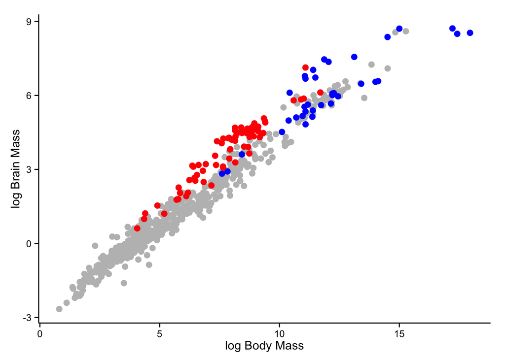

```r
library(ggplot2)
mammal.scatter <- ggplot(data=other.mammals, aes(x=logBody.Mass, y=logBrain.Mass)) +
  theme_classic() + geom_point(size=3, col="grey") +
  labs(x="log Body Mass", y="log Brain Mass")
cetartiodactyla.scatter <- geom_point(data=cetartiodactyla, size=3, col="blue")
primates.scatter <- geom_point(data=primates, size=3, col="red")
scatter <- mammal.scatter+cetartiodactyla.scatter+primates.scatter
scatter
```

Next, create linear models for Primates, Cetartiodactyla, and other mammals and plot the regression lines on top of the scatter plot.

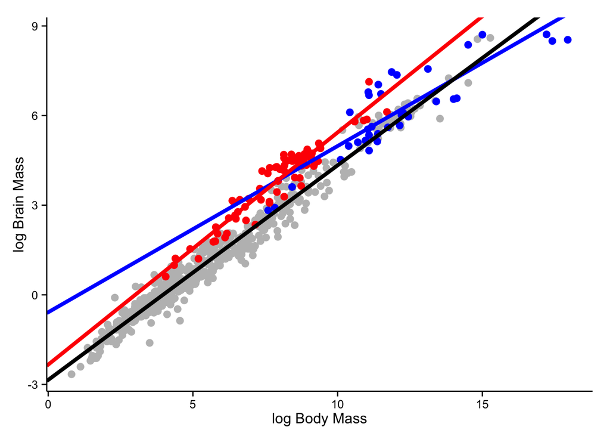

```r
cetartiodactyla.lm <- lm(data=cetartiodactyla, logBrain.Mass~logBody.Mass)
primates.lm <- lm(data=primates, logBrain.Mass~logBody.Mass)
other.mammals.lm <- lm(data=other.mammals, logBrain.Mass~logBody.Mass)
all.mammals.lm <- lm(data=all.mammals, logBrain.Mass~logBody.Mass)

cetartiodactyla.line <- geom_abline(slope=0.5565, intercept=-0.5839, col="blue", size=1.5)
primates.line <- geom_abline(slope=0.7774, intercept=-2.3373, col="red", size=1.5)
other.mammals.line <- geom_abline(slope=0.7184, intercept=-2.8490, size=1.5)
all.mammals.line <- geom_abline(slope= 0.7456, intercept=-2.8842, size=1.5)
scatter.lines <- scatter+cetartiodactyla.line+primates.line+other.mammals.line
scatter.lines
```

We can see that the slopes for Primates, Cetartiodactyla, and the other mammals are not the same. We use ANCOVA to test whether this visual difference is significant.

```r
brains$is.primate <- brains$Order=="Primates"
brains$is.cetartiodactyla <- brains$Order=="Cetartiodactyla"
head(brains)
```

```
##                 Species.Name           Order Brain.Mass..g. Body.Mass..g.
## 1               Homo sapiens        Primates        1250.43      65142.86
## 2          Phocoena phocoena Cetartiodactyla        1735.00     142430.00
## 3 Lagenorhynchus obliquidens Cetartiodactyla        1136.75      89750.00
## 4      Stenella coeruleoalba Cetartiodactyla         883.75      63500.00
## 5         Tursiops truncatus Cetartiodactyla        1573.00     170480.00
## 6          Delphinus delphis Cetartiodactyla         797.26      65086.96
##     EQ Independent.contrast.derived.EQ PGLS.ML.dervived.EQ
## 1 5.72                       1.1491544           12.633650
## 2 4.43                       0.9732993           10.962980
## 3 4.10                       0.8534335            9.476202
## 4 4.12                       0.8253700            9.066825
## 5 3.51                       0.7877916            8.923060
## 6 3.65                       0.7330865            8.059241
##                                                  Reference Notes
## 1                          Sherwood/this study; Nowak 1991
## 2               Crile & Quiring 1940; Silva & Downing 1995
## 3                                      Ridgway et al. 1966
## 4              Pilleri & Busnel 1969; Silva & Downing 1995
## 5                         Marino 2000; Ridgway et al. 1966
## 6 Marino 2000; Pilleri & Busnel 1969; Silva & Downing 1995
##   logBody.Mass logBrain.Mass is.primate is.cetartiodactyla
## 1     11.08434      7.131243       TRUE              FALSE
## 2     11.86661      7.458763      FALSE               TRUE
## 3     11.40478      7.035929      FALSE               TRUE
## 4     11.05880      6.784174      FALSE               TRUE
## 5     12.04637      7.360740      FALSE               TRUE
## 6     11.08348      6.681181      FALSE               TRUE
```

Finally, we will perform an ANCOVA for both Primates and Cetartiodactyla. We will use the slope.com() function that is part of the package “smatr”. Note that this package is using reduced/standardized major axis regression to perform the ANOVA.

```r
library(smatr)
slope.com(x=brains$logBody.Mass, y=brains$logBrain.Mass, groups=brains$is.primate, method="SMA")
```

```
## $LR
## [1] 7.820704
##
## $p
## [1] 0.005165107
##
## $b
## [1] 0.7386463
##
## $ci
## [1] 0.7281666 0.7491392
##
## $varb
## [1] 2.827338e-05
##
## $lambda
## [1] 0.5455984
##
## $bs
##                  FALSE      TRUE
## slope        0.7356969 0.8159395
## lower.CI.lim 0.7251702 0.7605697
## upper.CI.lim 0.7463765 0.8753402
##
## $df
## [1] 1
```

```r
slope.com(x=brains$logBody.Mass, y=brains$logBrain.Mass, groups=brains$is.cetartiodactyla, method="SMA")
```

```
## $LR
## [1] 4.622684
##
## $p
## [1] 0.03155183
##
## $b
## [1] 0.7698437
##
## $ci
## [1] 0.7563729 0.7837510
##
## $varb
## [1] 4.843856e-05
##
## $lambda
## [1] 0.5926593
##
## $bs
##                  FALSE      TRUE
## slope        0.7714072 0.6375615
## lower.CI.lim 0.7577637 0.5368360
## upper.CI.lim 0.7852965 0.7571861
##
## $df
## [1] 1
```

From the readout, we can see that there is a significant difference between the slopes of Primates and all other mammals and Cetartiodactyla and all other mammals. We can also see the RMA/SMA slopes and their confidence intervals in the bottom table.

If we’re just interested in performing ANCOVA with OLS regression, we can use the lm() function.

```r
primate.ancova <- lm(data=brains, logBrain.Mass~logBody.Mass+is.primate)
coef(primate.ancova)
```

```
##    (Intercept)   logBody.Mass is.primateTRUE
##     -2.8772319      0.7263188      0.9436809
```

```r
anova(primate.ancova)
```

```
## Analysis of Variance Table
##
## Response: logBrain.Mass
##               Df Sum Sq Mean Sq  F value    Pr(>F)
## logBody.Mass   1 3360.5  3360.5 20607.05 < 2.2e-16 ***
## is.primate     1   57.3    57.3   351.24 < 2.2e-16 ***
## Residuals    627  102.2     0.2
## ---
## Signif. codes:  0 '***' 0.001 '**' 0.01 '*' 0.05 '.' 0.1 ' ' 1
```

```r
cetartiodactyla.ancova <- lm(data=brains, logBrain.Mass~logBody.Mass+is.cetartiodactyla)
coef(cetartiodactyla.ancova)
```

```
##            (Intercept)           logBody.Mass is.cetartiodactylaTRUE
##            -2.88012018             0.74467791             0.02609411
```

```r
anova(cetartiodactyla.ancova)
```

```
## Analysis of Variance Table
##
## Response: logBrain.Mass
##                     Df Sum Sq Mean Sq    F value Pr(>F)
## logBody.Mass         1 3360.5  3360.5 13209.4479 <2e-16 ***
## is.cetartiodactyla   1    0.0     0.0     0.0703  0.791
## Residuals          627  159.5     0.3
## ---
## Signif. codes:  0 '***' 0.001 '**' 0.01 '*' 0.05 '.' 0.1 ' ' 1
```

When we use OLS, Primates is significantly different from all othermammals, but Cetartiodactyla is not. This highlights the differences between OLS and RMA/SMA. In this case, since there is error in both the x and y measurements, the RMA/SMA regression is more appropriate.